# The Relationship between Productivity and Minimum Wage from 1948 to 2018

Jane Huber & Meghan Mokate

3/23/2021

# Introduction

The US currently faces rising inequality, stagnating wages, and an ongoing debate around the federal minimum wage. This analysis seeks to join that conversation by examining the relationship between the federal minimum wage, inflation, and economic productivity. We feel that this research could indicate how appropriate or inappropriate the current federal minimum wage is in order to inform opinions regarding the wage increase discussions. By considering minimum wage changes over time, we can reflect on past policy, determine trends in context, and assess the validity of a case to increase minimum wage in the United States in the present day.

We hope to examine how federal minimum wage in the United States has changed over time in relation to productivity and inflation, examining available data from 1948-2018. Specifically, we would like to assess what the expected minimum wage would be over time if it were consistently adjusted for inflation and increased according to productivity gains. We will compare this to what the actual minimum wage was year to year.

```r
master_set$ann_inflat <- (master_set$`Annual Inflation`) / 100

master_set$`Net Productivity Change` <- vector("numeric", 71)

for (i in seq(nrow(master_set))) {
  if (i == 1) {
    master_set$`Net Productivity Change`[i] <- 0
  } else {
    master_set$`Net Productivity Change`[i] <- ((master_set$`Net Productivity`[i] - master_set$`Net Productivity`[i - 1]))}
}

master_set <- master_set %>%
  mutate(`Net Productivity Change` = (`Net Productivity Change` / 100))

master_set$increase_calc <- master_set$ann_inflat + master_set$`Net Productivity Change`

master_set$increase_act <- vector("numeric", 71)

for (i in seq(nrow(master_set))) {
  if (i == 1) {
    master_set$increase_act[i] <- 0
  } else {
    master_set$increase_act[i] <- ((master_set$`Minimum Wage`[i] - master_set$`Minimum Wage`[i - 1])/master_set$`Minimum Wage`[i - 1])} # CHECK THIS FORMULA
}

master_set$incr_diff <- master_set$increase_calc - master_set$increase_act

master_set$accum_incr_calc <- vector("numeric", 71)

for (i in seq(nrow(master_set))) {
  if (i == 1) {
    master_set$accum_incr_calc[i] <- 0
  } else {
    master_set$accum_incr_calc[i] <- ((master_set$increase_calc[i] + master_set$accum_incr_calc[i - 1]))}
}

master_set$accum_incr_act <- vector("numeric", 71)

for (i in seq(nrow(master_set))) {
  if (i == 1) {
    master_set$accum_incr_act[i] <- 0
  } else {
    master_set$accum_incr_act[i] <- ((master_set$increase_act[i] + master_set$accum_incr_act[i - 1]))}
}

master_set_1 <- master_set %>%
  pivot_longer(cols = c(increase_calc, increase_act, accum_incr_act, accum_incr_calc),
               names_to = "Increase Type",
               values_to = "Increase Amount")
```

## Create a Theme

```r
# feel free to edit this however! just thought I'd throw in a theme draft
# colors are probably too similar

wage_theme <-
  theme_minimal() +
  theme(
    text = element_text(family = "Georgia"),
    plot.title = element_text(face = "bold", size = 16, color = "seagreen"),
    plot.subtitle = element_text(face = "italic", size = 14, color = "royalblue4"),
    axis.title = element_text(size = 14, face = "bold", color = "seagreen"),
    axis.text = element_text(size = 12, color = "navyblue"),
    axis.line = element_blank(),
    axis.ticks = element_blank(),
    axis.text.x = element_text(angle = 90),
    legend.title = element_text(size = 12, face = "bold", color = "seagreen"),
    legend.text = element_text(size = 12, color = "navyblue"))
  #  plot.caption = element_text(color = "navyblue", size = 10))
```

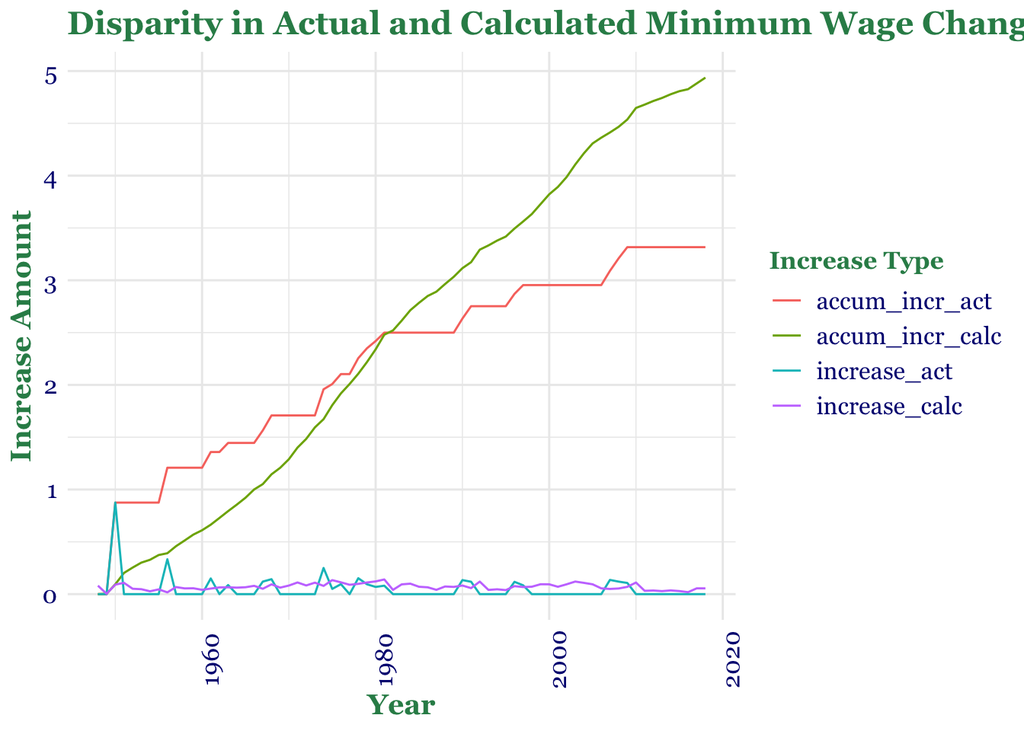

```r
ggplot() +
  geom_path(data = master_set_1, aes(x = Year, y = `Increase Amount`, color = `Increase Type`)) +
  labs(title = "Disparity in Actual and Calculated Minimum Wage Changes") +
  wage_theme
```

# Preliminary Data Exploration

# Regression Datasets and Analysis

```r
# Add in regression datasets

# Create dummy variable for when there was a change in minimum wage
regress_set <- master_set %>%
  mutate(change = ifelse(increase_act == 0, 0, 1))


# Unemployment dataset; source: https://data.bls.gov/pdq/SurveyOutputServlet
unemploy <- read_csv('unemploy.csv') %>%
  row_to_names(row_number = 11) %>%
  mutate_if(is.character,as.numeric) %>%
  rowwise() %>%
  mutate(avg_unemploy = mean(c_across(2:13))) %>%
  select(1, 14) %>%
  mutate(avg_unemploy = (avg_unemploy / 100))
unemploy
```

| Year | avg_unemploy |
| --- | --- |
| 1948 | 0.03750000 |
| 1949 | 0.06050000 |
| 1950 | 0.05208333 |
| 1951 | 0.03283333 |
| 1952 | 0.03025000 |
| 1953 | 0.02925000 |
| 1954 | 0.05591667 |
| 1955 | 0.04366667 |
| 1956 | 0.04125000 |
| 1957 | 0.04300000 |

[output cut: 61 more lines]

```r
regress_set_a <- left_join(regress_set, unemploy, by="Year")
regress_set_a
```

| Year | Hourly Compensation | Net Productivity | Minimum Wage | Annual Inflation | ann_inflat | Net Productivity Change | increase_calc | increase_act | incr_diff | accum_incr_calc | accum_incr_act | change | avg_unemploy |
| --- | --- | --- | --- | --- | --- | --- | --- | --- | --- | --- | --- | --- | --- |
| 1948 | 0.00 | 0.00 | 0.40 | 8.1 | 0.081 | 0.0000 | 0.0810 | 0.00000000 | 0.08100000 | 0.0000 | 0.000000 | 0 | 0.03750000 |
| 1949 | 6.24 | 1.55 | 0.40 | -1.2 | -0.012 | 0.0155 | 0.0035 | 0.00000000 | 0.00350000 | 0.0035 | 0.000000 | 0 | 0.06050000 |
| 1950 | 10.46 | 9.34 | 0.75 | 1.3 | 0.013 | 0.0779 | 0.0909 | 0.87500000 | -0.78410000 | 0.0944 | 0.875000 | 1 | 0.05208333 |
| 1951 | 11.74 | 12.24 | 0.75 | 7.9 | 0.079 | 0.0290 | 0.1080 | 0.00000000 | 0.10800000 | 0.2024 | 0.875000 | 0 | 0.03283333 |
| 1952 | 15.02 | 15.49 | 0.75 | 1.9 | 0.019 | 0.0325 | 0.0515 | 0.00000000 | 0.05150000 | 0.2539 | 0.875000 | 0 | 0.03025000 |
| 1953 | 20.82 | 19.41 | 0.75 | 0.8 | 0.008 | 0.0392 | 0.0472 | 0.00000000 | 0.04720000 | 0.3011 | 0.875000 | 0 | 0.02925000 |
| 1954 | 23.48 | 21.44 | 0.75 | 0.7 | 0.007 | 0.0203 | 0.0273 | 0.00000000 | 0.02730000 | 0.3284 | 0.875000 | 0 | 0.05591667 |
| 1955 | 28.70 | 26.38 | 0.75 | -0.4 | -0.004 | 0.0494 | 0.0454 | 0.00000000 | 0.04540000 | 0.3738 | 0.875000 | 0 | 0.04366667 |
| 1956 | 33.89 | 26.59 | 1.00 | 1.5 | 0.015 | 0.0021 | 0.0171 | 0.33333333 | -0.31623333 | 0.3909 | 1.208333 | 1 | 0.04125000 |
| 1957 | 37.08 | 30.04 | 1.00 | 3.3 | 0.033 | 0.0345 | 0.0675 | 0.00000000 | 0.06750000 | 0.4584 | 1.208333 | 0 | 0.04300000 |

[output cut: 61 more lines]

```r
# Presidential party for each year dataset; source: https://github.com/awhstin/Dataset-List/blob/master/presidents.csv

presidents <- read_csv('presidents.csv') %>%
  cSplit("President Name,Years In Office,Number,Party", ",") %>%
  rename(president = "President Name,Years In Office,Number,Party_1",
         years = "President Name,Years In Office,Number,Party_2",
         number = "President Name,Years In Office,Number,Party_3",
         party = "President Name,Years In Office,Number,Party_4") %>%
  separate(years, c("start_year", "end_year"), sep = "-") %>%
  mutate(end_year = ifelse(president == "William H. Harrison", 1841, end_year)) %>%
  mutate(end_year = ifelse(president == "Donald Trump", 2021, end_year)) %>%
  pivot_longer(cols = c(start_year, end_year),
               names_to = "start_end",
               values_to = "Year",
               values_transform = list("Year"=as.numeric)) %>%
  select(1, 3, 5)
regress_set_b <- left_join(regress_set_a, presidents, by="Year")
regress_set_b
```

| Year | Hourly Compensation | Net Productivity | Minimum Wage | Annual Inflation | ann_inflat | Net Productivity Change | increase_calc | increase_act | incr_diff | accum_incr_calc | accum_incr_act | change | avg_unemploy | president | party |
| --- | --- | --- | --- | --- | --- | --- | --- | --- | --- | --- | --- | --- | --- | --- | --- |
| 1948 | 0.00 | 0.00 | 0.40 | 8.1 | 0.081 | 0.0000 | 0.0810 | 0.00000000 | 0.08100000 | 0.0000 | 0.000000 | 0 | 0.03750000 | NA | NA |
| 1949 | 6.24 | 1.55 | 0.40 | -1.2 | -0.012 | 0.0155 | 0.0035 | 0.00000000 | 0.00350000 | 0.0035 | 0.000000 | 0 | 0.06050000 | NA | NA |
| 1950 | 10.46 | 9.34 | 0.75 | 1.3 | 0.013 | 0.0779 | 0.0909 | 0.87500000 | -0.78410000 | 0.0944 | 0.875000 | 1 | 0.05208333 | NA | NA |
| 1951 | 11.74 | 12.24 | 0.75 | 7.9 | 0.079 | 0.0290 | 0.1080 | 0.00000000 | 0.10800000 | 0.2024 | 0.875000 | 0 | 0.03283333 | NA | NA |
| 1952 | 15.02 | 15.49 | 0.75 | 1.9 | 0.019 | 0.0325 | 0.0515 | 0.00000000 | 0.05150000 | 0.2539 | 0.875000 | 0 | 0.03025000 | NA | NA |
| 1953 | 20.82 | 19.41 | 0.75 | 0.8 | 0.008 | 0.0392 | 0.0472 | 0.00000000 | 0.04720000 | 0.3011 | 0.875000 | 0 | 0.02925000 | Harry S. Truman | Democratic |
| 1953 | 20.82 | 19.41 | 0.75 | 0.8 | 0.008 | 0.0392 | 0.0472 | 0.00000000 | 0.04720000 | 0.3011 | 0.875000 | 0 | 0.02925000 | Dwight D. Eisenhower | Republican |
| 1954 | 23.48 | 21.44 | 0.75 | 0.7 | 0.007 | 0.0203 | 0.0273 | 0.00000000 | 0.02730000 | 0.3284 | 0.875000 | 0 | 0.05591667 | NA | NA |
| 1955 | 28.70 | 26.38 | 0.75 | -0.4 | -0.004 | 0.0494 | 0.0454 | 0.00000000 | 0.04540000 | 0.3738 | 0.875000 | 0 | 0.04366667 | NA | NA |
| 1956 | 33.89 | 26.59 | 1.00 | 1.5 | 0.015 | 0.0021 | 0.0171 | 0.33333333 | -0.31623333 | 0.3909 | 1.208333 | 1 | 0.04125000 | NA | NA |

[output cut: 73 more lines]

```r
regress_set_b_1 <- regress_set_b %>%
  fill(president, .direction = "up") %>%
  fill(party, .direction = "up")
regress_set_b_1
```

| Year | Hourly Compensation | Net Productivity | Minimum Wage | Annual Inflation | ann_inflat | Net Productivity Change | increase_calc | increase_act | incr_diff | accum_incr_calc | accum_incr_act | change | avg_unemploy | president | party |
| --- | --- | --- | --- | --- | --- | --- | --- | --- | --- | --- | --- | --- | --- | --- | --- |
| 1948 | 0.00 | 0.00 | 0.40 | 8.1 | 0.081 | 0.0000 | 0.0810 | 0.00000000 | 0.08100000 | 0.0000 | 0.000000 | 0 | 0.03750000 | Harry S. Truman | Democratic |
| 1949 | 6.24 | 1.55 | 0.40 | -1.2 | -0.012 | 0.0155 | 0.0035 | 0.00000000 | 0.00350000 | 0.0035 | 0.000000 | 0 | 0.06050000 | Harry S. Truman | Democratic |
| 1950 | 10.46 | 9.34 | 0.75 | 1.3 | 0.013 | 0.0779 | 0.0909 | 0.87500000 | -0.78410000 | 0.0944 | 0.875000 | 1 | 0.05208333 | Harry S. Truman | Democratic |
| 1951 | 11.74 | 12.24 | 0.75 | 7.9 | 0.079 | 0.0290 | 0.1080 | 0.00000000 | 0.10800000 | 0.2024 | 0.875000 | 0 | 0.03283333 | Harry S. Truman | Democratic |
| 1952 | 15.02 | 15.49 | 0.75 | 1.9 | 0.019 | 0.0325 | 0.0515 | 0.00000000 | 0.05150000 | 0.2539 | 0.875000 | 0 | 0.03025000 | Harry S. Truman | Democratic |
| 1953 | 20.82 | 19.41 | 0.75 | 0.8 | 0.008 | 0.0392 | 0.0472 | 0.00000000 | 0.04720000 | 0.3011 | 0.875000 | 0 | 0.02925000 | Harry S. Truman | Democratic |
| 1953 | 20.82 | 19.41 | 0.75 | 0.8 | 0.008 | 0.0392 | 0.0472 | 0.00000000 | 0.04720000 | 0.3011 | 0.875000 | 0 | 0.02925000 | Dwight D. Eisenhower | Republican |
| 1954 | 23.48 | 21.44 | 0.75 | 0.7 | 0.007 | 0.0203 | 0.0273 | 0.00000000 | 0.02730000 | 0.3284 | 0.875000 | 0 | 0.05591667 | Dwight D. Eisenhower | Republican |
| 1955 | 28.70 | 26.38 | 0.75 | -0.4 | -0.004 | 0.0494 | 0.0454 | 0.00000000 | 0.04540000 | 0.3738 | 0.875000 | 0 | 0.04366667 | Dwight D. Eisenhower | Republican |
| 1956 | 33.89 | 26.59 | 1.00 | 1.5 | 0.015 | 0.0021 | 0.0171 | 0.33333333 | -0.31623333 | 0.3909 | 1.208333 | 1 | 0.04125000 | Dwight D. Eisenhower | Republican |

[output cut: 73 more lines]

```r
regress_set_b_2 <- regress_set_b_1 %>%
  fill(president, .direction = "down") %>%
  fill(party, .direction = "down")
regress_set_b_2
```

| Year | Hourly Compensation | Net Productivity | Minimum Wage | Annual Inflation | ann_inflat | Net Productivity Change | increase_calc | increase_act | incr_diff | accum_incr_calc | accum_incr_act | change | avg_unemploy | president | party |
| --- | --- | --- | --- | --- | --- | --- | --- | --- | --- | --- | --- | --- | --- | --- | --- |
| 1948 | 0.00 | 0.00 | 0.40 | 8.1 | 0.081 | 0.0000 | 0.0810 | 0.00000000 | 0.08100000 | 0.0000 | 0.000000 | 0 | 0.03750000 | Harry S. Truman | Democratic |
| 1949 | 6.24 | 1.55 | 0.40 | -1.2 | -0.012 | 0.0155 | 0.0035 | 0.00000000 | 0.00350000 | 0.0035 | 0.000000 | 0 | 0.06050000 | Harry S. Truman | Democratic |
| 1950 | 10.46 | 9.34 | 0.75 | 1.3 | 0.013 | 0.0779 | 0.0909 | 0.87500000 | -0.78410000 | 0.0944 | 0.875000 | 1 | 0.05208333 | Harry S. Truman | Democratic |
| 1951 | 11.74 | 12.24 | 0.75 | 7.9 | 0.079 | 0.0290 | 0.1080 | 0.00000000 | 0.10800000 | 0.2024 | 0.875000 | 0 | 0.03283333 | Harry S. Truman | Democratic |
| 1952 | 15.02 | 15.49 | 0.75 | 1.9 | 0.019 | 0.0325 | 0.0515 | 0.00000000 | 0.05150000 | 0.2539 | 0.875000 | 0 | 0.03025000 | Harry S. Truman | Democratic |
| 1953 | 20.82 | 19.41 | 0.75 | 0.8 | 0.008 | 0.0392 | 0.0472 | 0.00000000 | 0.04720000 | 0.3011 | 0.875000 | 0 | 0.02925000 | Harry S. Truman | Democratic |
| 1953 | 20.82 | 19.41 | 0.75 | 0.8 | 0.008 | 0.0392 | 0.0472 | 0.00000000 | 0.04720000 | 0.3011 | 0.875000 | 0 | 0.02925000 | Dwight D. Eisenhower | Republican |
| 1954 | 23.48 | 21.44 | 0.75 | 0.7 | 0.007 | 0.0203 | 0.0273 | 0.00000000 | 0.02730000 | 0.3284 | 0.875000 | 0 | 0.05591667 | Dwight D. Eisenhower | Republican |
| 1955 | 28.70 | 26.38 | 0.75 | -0.4 | -0.004 | 0.0494 | 0.0454 | 0.00000000 | 0.04540000 | 0.3738 | 0.875000 | 0 | 0.04366667 | Dwight D. Eisenhower | Republican |
| 1956 | 33.89 | 26.59 | 1.00 | 1.5 | 0.015 | 0.0021 | 0.0171 | 0.33333333 | -0.31623333 | 0.3909 | 1.208333 | 1 | 0.04125000 | Dwight D. Eisenhower | Republican |

[output cut: 73 more lines]

```r
regress_set_b_2 <- regress_set_b_2[!duplicated(regress_set_b_2$Year, fromLast = T), ]

# Add in population dataset; source: https://usafacts.org/data/topics/people-society/population-and-demographics/population-data/population/#chart-12818-0

population_source <- read_csv('population_usafacts.csv')
population <- population_source %>%
  filter(Years == "Population (People)") %>%
  select(50:122) %>%
  pivot_longer(1:73,
               names_to = "Year",
               values_to = "population",
               names_transform = list("Year"=as.numeric))

regress_set_c <- left_join(regress_set_b_2, population, by="Year")
regress_set_c
```

| Year | Hourly Compensation | Net Productivity | Minimum Wage | Annual Inflation | ann_inflat | Net Productivity Change | increase_calc | increase_act | incr_diff | accum_incr_calc | accum_incr_act | change | avg_unemploy | president | party | population |
| --- | --- | --- | --- | --- | --- | --- | --- | --- | --- | --- | --- | --- | --- | --- | --- | --- |
| 1948 | 0.00 | 0.00 | 0.40 | 8.1 | 0.081 | 0.0000 | 0.0810 | 0.00000000 | 0.08100000 | 0.0000 | 0.000000 | 0 | 0.03750000 | Harry S. Truman | Democratic | 146631302 |
| 1949 | 6.24 | 1.55 | 0.40 | -1.2 | -0.012 | 0.0155 | 0.0035 | 0.00000000 | 0.00350000 | 0.0035 | 0.000000 | 0 | 0.06050000 | Harry S. Truman | Democratic | 149188130 |
| 1950 | 10.46 | 9.34 | 0.75 | 1.3 | 0.013 | 0.0779 | 0.0909 | 0.87500000 | -0.78410000 | 0.0944 | 0.875000 | 1 | 0.05208333 | Harry S. Truman | Democratic | 152271417 |
| 1951 | 11.74 | 12.24 | 0.75 | 7.9 | 0.079 | 0.0290 | 0.1080 | 0.00000000 | 0.10800000 | 0.2024 | 0.875000 | 0 | 0.03283333 | Harry S. Truman | Democratic | 154877889 |
| 1952 | 15.02 | 15.49 | 0.75 | 1.9 | 0.019 | 0.0325 | 0.0515 | 0.00000000 | 0.05150000 | 0.2539 | 0.875000 | 0 | 0.03025000 | Harry S. Truman | Democratic | 157552740 |
| 1953 | 20.82 | 19.41 | 0.75 | 0.8 | 0.008 | 0.0392 | 0.0472 | 0.00000000 | 0.04720000 | 0.3011 | 0.875000 | 0 | 0.02925000 | Dwight D. Eisenhower | Republican | 160184192 |
| 1954 | 23.48 | 21.44 | 0.75 | 0.7 | 0.007 | 0.0203 | 0.0273 | 0.00000000 | 0.02730000 | 0.3284 | 0.875000 | 0 | 0.05591667 | Dwight D. Eisenhower | Republican | 163025854 |
| 1955 | 28.70 | 26.38 | 0.75 | -0.4 | -0.004 | 0.0494 | 0.0454 | 0.00000000 | 0.04540000 | 0.3738 | 0.875000 | 0 | 0.04366667 | Dwight D. Eisenhower | Republican | 165931202 |
| 1956 | 33.89 | 26.59 | 1.00 | 1.5 | 0.015 | 0.0021 | 0.0171 | 0.33333333 | -0.31623333 | 0.3909 | 1.208333 | 1 | 0.04125000 | Dwight D. Eisenhower | Republican | 168903031 |
| 1957 | 37.08 | 30.04 | 1.00 | 3.3 | 0.033 | 0.0345 | 0.0675 | 0.00000000 | 0.06750000 | 0.4584 | 1.208333 | 0 | 0.04300000 | Dwight D. Eisenhower | Republican | 171984130 |

[output cut: 61 more lines]

```r
regress_set_c$pop_growth <- vector("numeric", 71)

for (i in seq(nrow(regress_set_c))) {
  if (i == 1) {
    regress_set_c$pop_growth[i] <- 0
  } else {
    regress_set_c$pop_growth[i] <- ((regress_set_c$population[i] - regress_set_c$population[i - 1])/regress_set_c$population[i - 1])}
} # Check calcs
```

# Exploratory Graphs

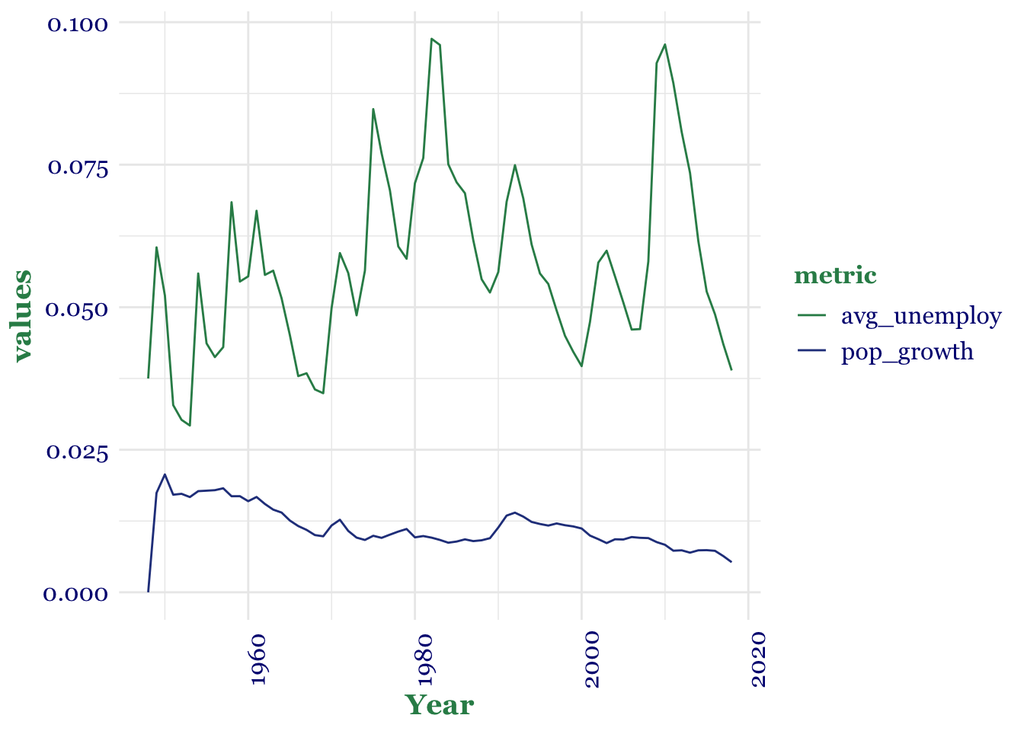

```r
# consider: how to add in change years to identify possible trends??
# most everything else is a year to year change except unemployment which is just a percentage...is this important?

regress_set_c %>%
  pivot_longer(cols = c(pop_growth, avg_unemploy),
                        names_to = "metric",
                        values_to = "values") %>%
  ggplot(aes(x = Year, y = values, group = metric, color = metric)) +
    geom_line() +
    scale_color_manual(values = c("avg_unemploy" = "seagreen", "pop_growth" = "royalblue4")) +
    wage_theme
```

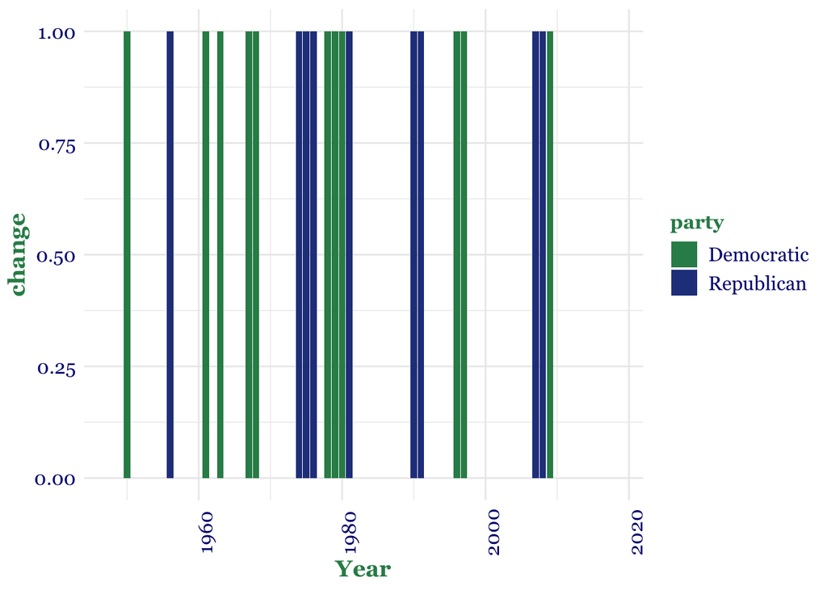

```r
# Changes in minimum wage and political party in power

ggplot(regress_set_c, aes(x = Year, y = change, fill = party)) +
  geom_col() +
  scale_fill_manual(values = c("Democratic" = "seagreen", "Republican" = "royalblue4")) +
  wage_theme
```

```r
# There seems to be no relationship between party and changes in minimum wage
```

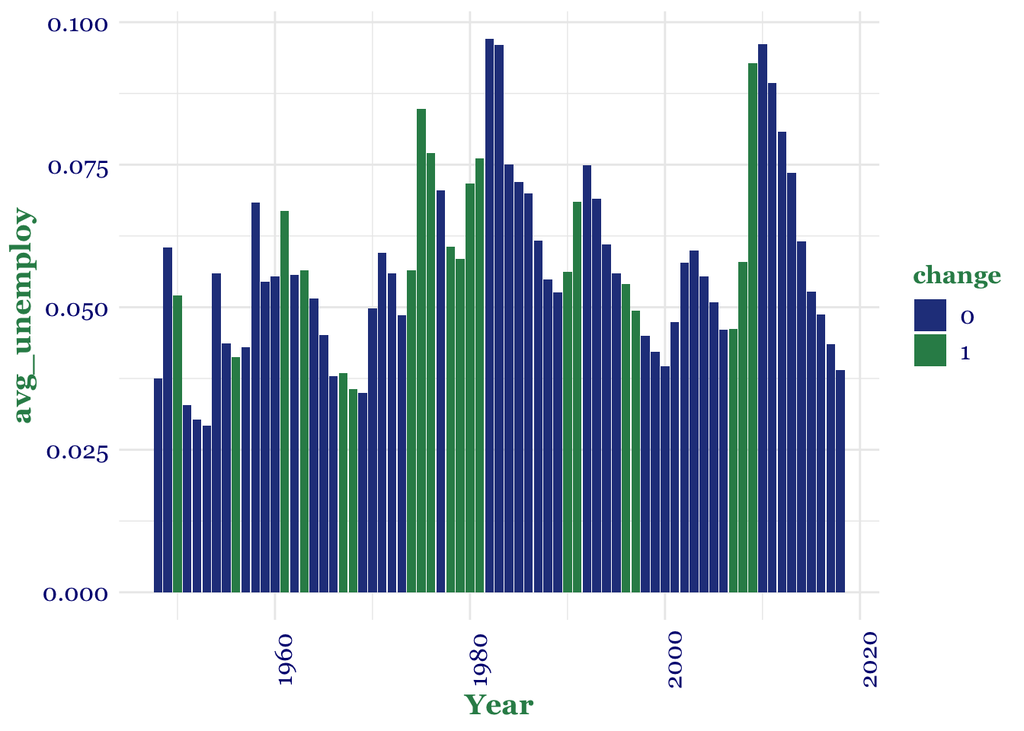

```r
# Changes in minimum wage and unemployment

regress_set_c %>%
  mutate(change = as.character(change)) %>%
  ggplot(aes(x = Year, y = avg_unemploy, fill = change)) +
    geom_col() +
    scale_fill_manual(values = c("1" = "seagreen", "0" = "royalblue4")) +
    wage_theme
```

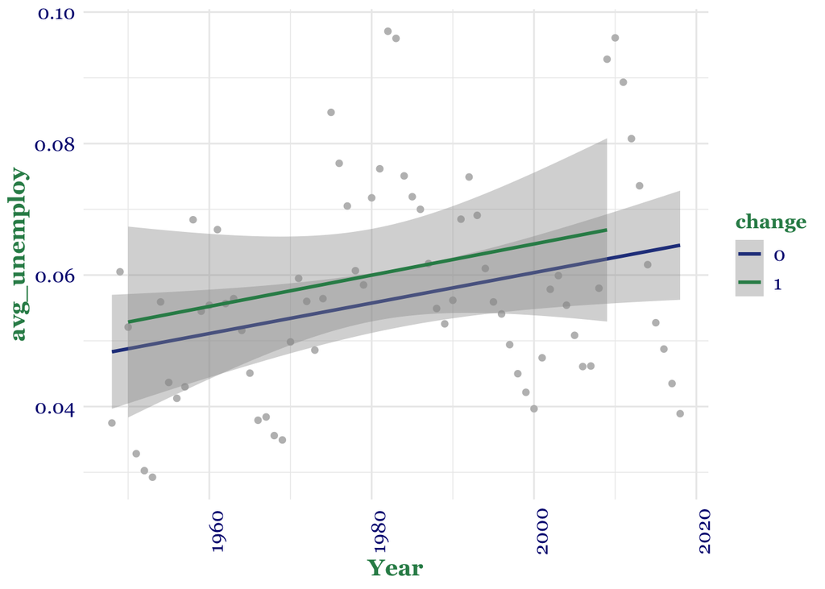

```r
regress_set_c %>%
  mutate(change = as.character(change)) %>%
  ggplot() +
    aes(x = Year, y = avg_unemploy, group = change, color = change) +
    geom_point(color = "grey") +
    geom_smooth(method = "lm") +
    scale_color_manual(values = c("1" = "seagreen", "0" = "royalblue4")) +
    wage_theme
```

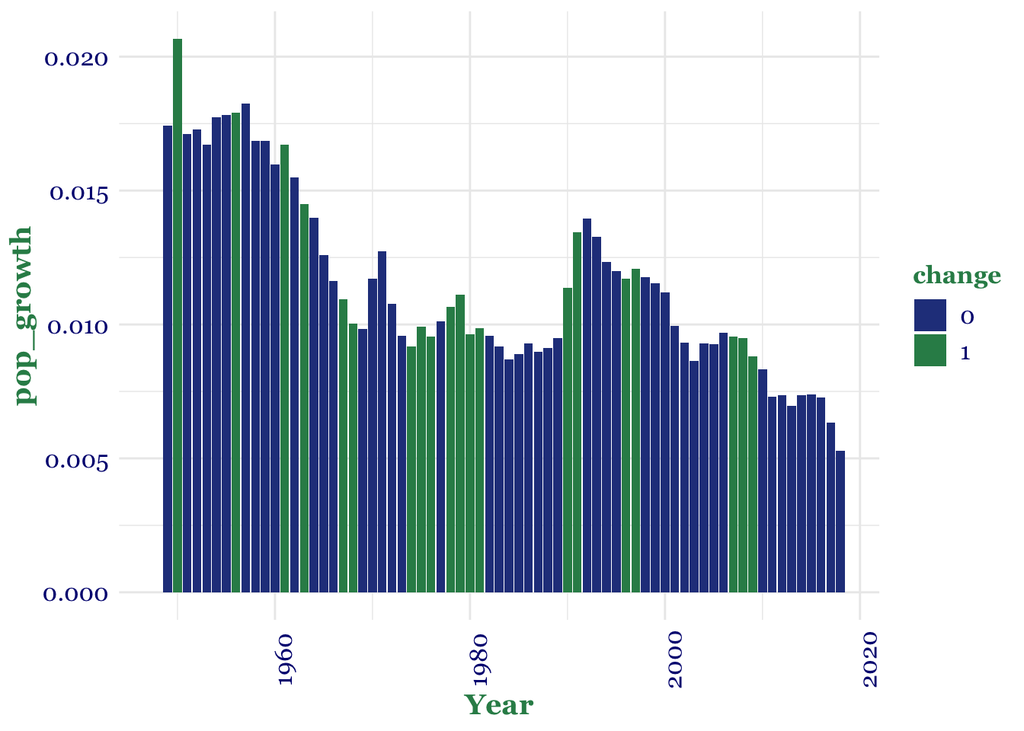

```r
# Changes in minimum wage and population

regress_set_c %>%
  mutate(change = as.character(change)) %>%
  ggplot(aes(x = Year, y = pop_growth, fill = change)) +
    geom_col() +
    scale_fill_manual(values = c("1" = "seagreen", "0" = "royalblue4")) +
    wage_theme
```

```r
min_wage_regress <- lm(data = regress_set_c, change ~ avg_unemploy + party + pop_growth)
summary(min_wage_regress)
```

```
##
## Call:
## lm(formula = change ~ avg_unemploy + party + pop_growth, data = regress_set_c)
##
## Residuals:
##     Min      1Q  Median      3Q     Max
## -0.4309 -0.3121 -0.2168  0.5659  0.8308
##
## Coefficients:
##                 Estimate Std. Error t value Pr(>|t|)
## (Intercept)     -0.02561    0.30132  -0.085    0.933
## avg_unemploy     3.55942    3.47754   1.024    0.310
## partyRepublican -0.10080    0.10845  -0.929    0.356
## pop_growth      13.74231   15.09737   0.910    0.366
##
## Residual standard error: 0.4552 on 67 degrees of freedom
## Multiple R-squared:  0.03345,    Adjusted R-squared:  -0.009831
## F-statistic: 0.7729 on 3 and 67 DF,  p-value: 0.5132
```

```r
# need to go back and review approaches to this
# need to add logs???
```

```r
# PROBABLY WILL NOT USE THIS!

# Calculate expected minimum wage based off inflation

master_set$ann_inflat <- (master_set$`Annual Inflation`) / 100

master_set$inflat_adj <- vector("numeric", 71)

for (i in seq(nrow(master_set))) {
  if (i == 1) {
    master_set$inflat_adj[i] <- master_set$`Minimum Wage`
  } else {
    master_set$inflat_adj[i] <- (master_set$inflat_adj[i - 1]*master_set$ann_inflat[i]) + master_set$inflat_adj[i-1]}
}

# Calculate expected minimum wage based off productivity

master_set <- master_set %>%
  mutate(net_prod_change = (`Net Productivity` - lag(`Net Productivity`, default = first(`Net Productivity`))))

master_set <- master_set %>%
  mutate(net_prod_change = (net_prod_change / 100))

master_set$prod_adj <- vector("numeric", 71)

for (i in seq(nrow(master_set))) {
  if (i == 1) {
    master_set$prod_adj[i] <- master_set$`Minimum Wage`
  } else {
    master_set$prod_adj[i] <- (master_set$prod_adj[i - 1]*master_set$net_prod_change[i]) + master_set$prod_adj[i-1]}
}


# Calculate expected minimum wage based off inflation AND productivity

master_set$net_impact <- master_set$ann_inflat + master_set$net_prod_change

master_set$inflat_prod_adj <- vector("numeric", 71)

for (i in seq(nrow(master_set))) {
  if (i == 1) {
    master_set$inflat_prod_adj[i] <- master_set$`Minimum Wage`
  } else {
    master_set$inflat_prod_adj[i] <- (master_set$inflat_prod_adj[i - 1]*master_set$net_impact[i]) + master_set$inflat_prod_adj[i-1]}
}

master_set
```

| Year | Hourly Compensation | Net Productivity | Minimum Wage | Annual Inflation | ann_inflat | Net Productivity Change | increase_calc | increase_act | incr_diff | accum_incr_calc | accum_incr_act | inflat_adj | net_prod_change | prod_adj | net_impact | inflat_prod_adj |
| --- | --- | --- | --- | --- | --- | --- | --- | --- | --- | --- | --- | --- | --- | --- | --- | --- |
| 1948 | 0.00 | 0.00 | 0.40 | 8.1 | 0.081 | 0.0000 | 0.0810 | 0.00000000 | 0.08100000 | 0.0000 | 0.000000 | 0.4000000 | 0.0000 | 0.4000000 | 0.0810 | 0.4000000 |
| 1949 | 6.24 | 1.55 | 0.40 | -1.2 | -0.012 | 0.0155 | 0.0035 | 0.00000000 | 0.00350000 | 0.0035 | 0.000000 | 0.3952000 | 0.0155 | 0.4062000 | 0.0035 | 0.4014000 |
| 1950 | 10.46 | 9.34 | 0.75 | 1.3 | 0.013 | 0.0779 | 0.0909 | 0.87500000 | -0.78410000 | 0.0944 | 0.875000 | 0.4003376 | 0.0779 | 0.4378430 | 0.0909 | 0.4378873 |
| 1951 | 11.74 | 12.24 | 0.75 | 7.9 | 0.079 | 0.0290 | 0.1080 | 0.00000000 | 0.10800000 | 0.2024 | 0.875000 | 0.4319643 | 0.0290 | 0.4505404 | 0.1080 | 0.4851791 |
| 1952 | 15.02 | 15.49 | 0.75 | 1.9 | 0.019 | 0.0325 | 0.0515 | 0.00000000 | 0.05150000 | 0.2539 | 0.875000 | 0.4401716 | 0.0325 | 0.4651830 | 0.0515 | 0.5101658 |
| 1953 | 20.82 | 19.41 | 0.75 | 0.8 | 0.008 | 0.0392 | 0.0472 | 0.00000000 | 0.04720000 | 0.3011 | 0.875000 | 0.4436930 | 0.0392 | 0.4834182 | 0.0472 | 0.5342456 |
| 1954 | 23.48 | 21.44 | 0.75 | 0.7 | 0.007 | 0.0203 | 0.0273 | 0.00000000 | 0.02730000 | 0.3284 | 0.875000 | 0.4467988 | 0.0203 | 0.4932316 | 0.0273 | 0.5488305 |
| 1955 | 28.70 | 26.38 | 0.75 | -0.4 | -0.004 | 0.0494 | 0.0454 | 0.00000000 | 0.04540000 | 0.3738 | 0.875000 | 0.4450116 | 0.0494 | 0.5175972 | 0.0454 | 0.5737474 |
| 1956 | 33.89 | 26.59 | 1.00 | 1.5 | 0.015 | 0.0021 | 0.0171 | 0.33333333 | -0.31623333 | 0.3909 | 1.208333 | 0.4516868 | 0.0021 | 0.5186841 | 0.0171 | 0.5835585 |
| 1957 | 37.08 | 30.04 | 1.00 | 3.3 | 0.033 | 0.0345 | 0.0675 | 0.00000000 | 0.06750000 | 0.4584 | 1.208333 | 0.4665925 | 0.0345 | 0.5365787 | 0.0675 | 0.6229487 |

[output cut: 61 more lines]